# Lecture 10 - Loneliness

# Background

## What is loneliness?

Loneliness and social isolation are often used interchangeably, which is confusing.

**Social isolation is objectively quantifiable**: the quantity and frequency of social contact, plus proximity to others.

**Loneliness is a subjective interpretation**: an evaluation that social needs are not being met satisfactorily.

(Cacioppo & Patrick, 2008; Perissinotto & Covinsky, 2014; Valtorta et al., 2016)

## Isolation versus loneliness

[figure not shown]

[figure not shown]

## Types of loneliness

**Social loneliness**: the absence of a desired social network (family, friends and acquaintances).

**Emotional loneliness**: the lack of attachment figure/s that one could form an intimate connection with.

(Dahlberg & McKee, 2014; Weiss, 1973)

## Physical versus social pain

- Physical pain is an aversive signal that evolved to minimise damage to one’s body.
- Loneliness is a social pain that may serve a similar function.

[figure not shown]

[figure not shown]

(Cacioppo & Hawkley, 2009)

## Health imapct

- Loneliness is associated with increased morbidity and mortality.
- It is clearly bad for your health and well-being.
- But is loneliness worse than smoking 15 cigarettes a day?

[figure not shown]

(Cacioppo & Patrick, 2008; Holt-Lunstad et al., 2015)

## Physiological impact

Loneliness predicts physiological responses associated with stress (e.g., elevated blood pressure, rise in cortisol), *above and beyond objective measures of social isolation*.

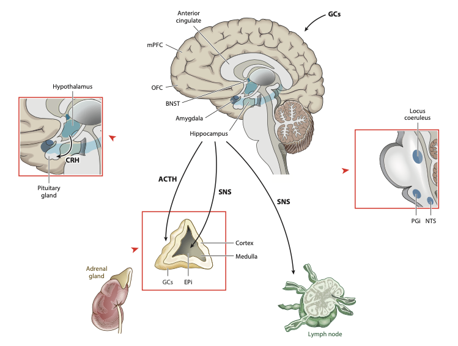

(Bruine de Bruin et al., 2020; Cacioppo et al., 2015)

## Psychological impact

Loneliness predicts maladaptive cognition and behavior (e.g., perception of social interactions as unpleasant, reduced physical activity, and lifetime satisfaction), *above and beyond objective measures of social isolation*.

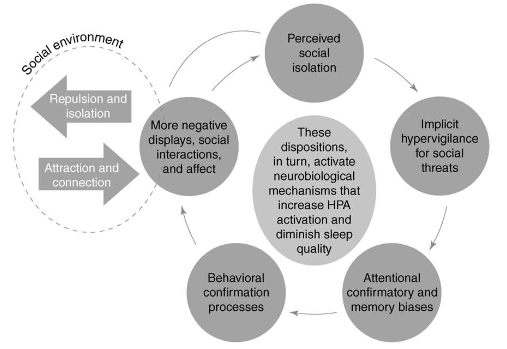

(Cacioppo & Hawkley, 2009)

## Basic research impact

- Loneliness offers a way to study individual differences in social neuroscience.
- Somewhat surprisingly, social neuroscience rarely studies variation in “socialness” across individuals.
- But things are changing…

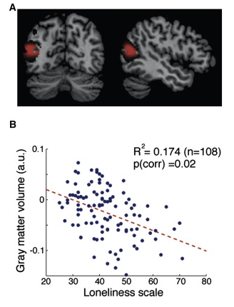

(Kanai et al., 2012)

# The reaffiliation model (RAM)

## RAM

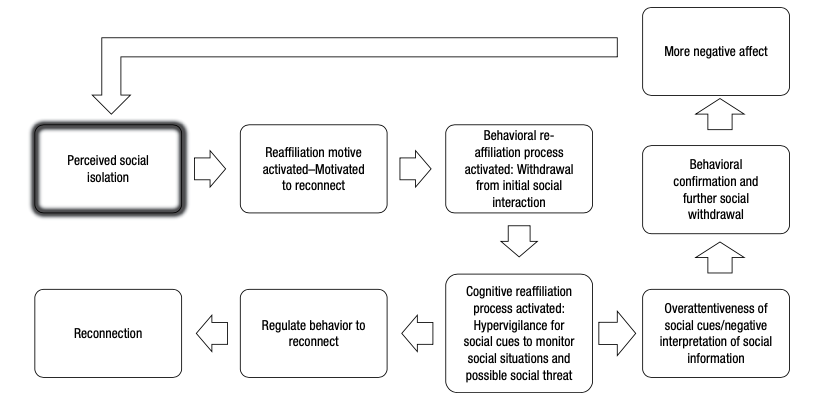

(Qualter et al., 2015)

# Neuroscience

## Structural changes

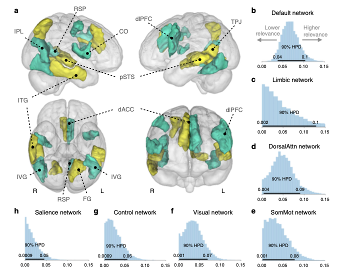

(Spreng et al., 2020)

## Functional changes

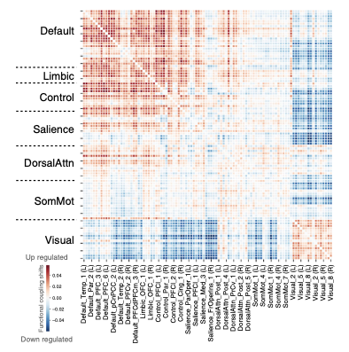

(Spreng et al., 2020)

# Brain injury

## Clinical observation

- Following a brain injury, such as a stroke, cognitive and social functions are impacted.
- Brain injury assessments routinely include an assessment of cognitive function.
- But what about social function and loneliness?

## Assessing loneliness following stroke

- The national survey for Wales dataset
- Two cohorts (2016/17 and 2017/18)
- De Jong Gierveld Loneliness Scale (Gierveld & Tilburg, 2006)
- N~8000 per cohort.

(Byrne et al., 2021)

## Loneliness ratings and stroke

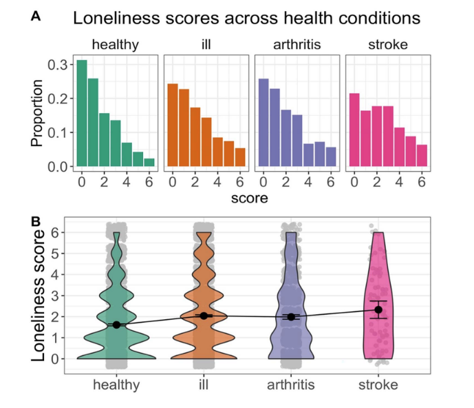

(Byrne et al., 2021)

## What about other illnesses?

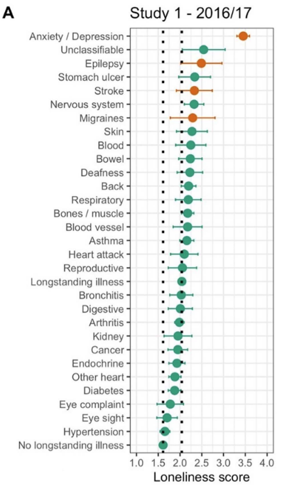

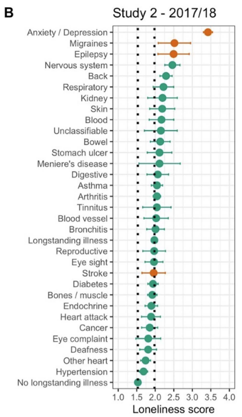

(Byrne et al., 2021)

# Lifespan

## social vs emotional

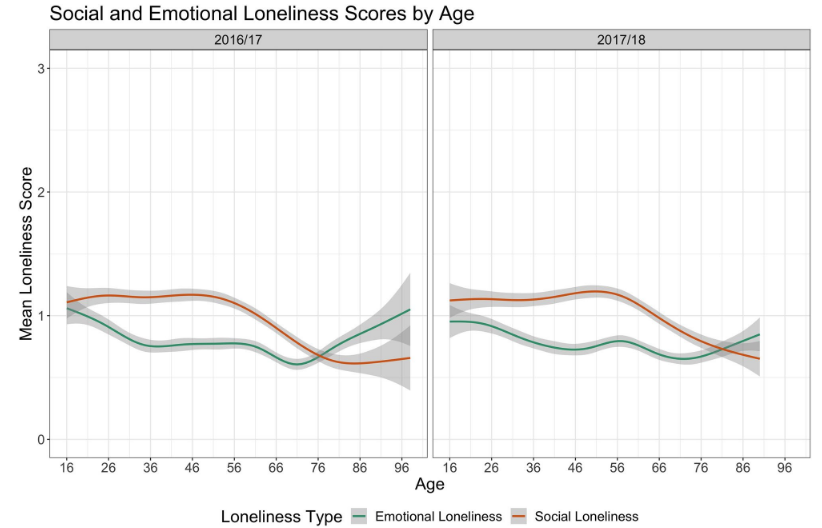

(Manoli et al., 2022)

# Interventions

## Are interventions effective?

- Sometimes, but not always.
- Effect sizes are modest.
- Not a one-size-fits-all solution.
- We lack a clear mechanistic understanding to guide interventions.

(Lasgaard et al., 2025; Masi et al., 2011; Morrish et al., 2023)

# Take a break

# Part 2 - Read and discuss

## Discussion material

- break into small groups (~ 5 per group)
- discuss aspects of the lecture
- discuss aspects of these articles:

Is loneliness worse than smoking 15 cigarettes a day?:

[BBC’s ‘More or less’ radio programme](https://www.bbc.com/audio/play/p0hncdtk)

There is **NOT** an epidemic of loneliness:

[Psychology Today](https://www.psychologytoday.com/us/blog/202504/loneliness-is-not-an-epidemic)

[The Conversation](https://theconversation.com/there-is-no-loneliness-epidemic-so-why-do-we-keep-talking-as-if-there-is-259072)

## References

Bruine de Bruin, W., Parker, A. M., & Strough, J. (2020). Age differences in reported social networks and well-being. *Psychology and Aging*, *35*(2), 159–168. https://doi.org/10.1037/pag0000415

Byrne, C., Saville, C. W. N., Coetzer, R., & Ramsey, R. (2021). Stroke Survivors Experience Elevated Levels of Loneliness: A Multi-Year Analysis of the National Survey for Wales. *Archives of Clinical Neuropsychology*, *47*(2), 390–407. https://doi.org/10.1093/arclin/acab046

Cacioppo, J. T., Cacioppo, S., Capitanio, J. P., & Cole, S. W. (2015). The Neuroendocrinology of Social Isolation. *Annual Review of Psychology*, *66*(1), 733–767. https://doi.org/10.1146/annurev-psych-010814-015240

Cacioppo, J. T., & Hawkley, L. C. (2009). Perceived social isolation and cognition. *Trends in Cognitive Sciences*, *13*(10), 447–454. https://doi.org/10.1016/j.tics.2009.06.005

Cacioppo, J. T., & Patrick, W. (2008). *Loneliness: Human Nature and the Need for Social Connection*. W. W. Norton & Company. https://books.google.com?id=w8pWZ2AGI4MC

Dahlberg, L., & McKee, K. J. (2014). Correlates of social and emotional loneliness in older people: Evidence from an English community study. *Aging & Mental Health*, *18*(4), 504–514. https://doi.org/10.1080/13607863.2013.856863

Gierveld, J. D. J., & Tilburg, T. V. (2006). A 6-Item Scale for Overall, Emotional, and Social Loneliness:Confirmatory Tests on Survey Data. *Research on Aging*, *28*(5), 582–598. https://doi.org/10.1177/0164027506289723

Holt-Lunstad, J., Smith, T. B., Baker, M., Harris, T., & Stephenson, D. (2015). Loneliness and Social Isolation as Risk Factors for Mortality:A Meta-Analytic Review. *Perspectives on Psychological Science*, *10*(2), 227–237. https://doi.org/10.1177/1745691614568352

Kanai, R., Bahrami, B., Duchaine, B., Janik, A., Banissy, M., & Rees, G. (2012). Brain Structure Links Loneliness to Social Perception. *Current Biology*, *22*(20), 1975–1979. https://doi.org/10.1016/j.cub.2012.08.045

Lasgaard, M., Qualter, P., Løvschall, C., Laustsen, L. M., Lim, M. H., Sjøl, S. E., Burke, L., Blæhr, E. E., Maindal, H. T., Hargaard, A.-S., Christensen, R., & Christiansen, J. (2025). Are loneliness interventions effective for reducing loneliness? A meta-analytic review of 280 studies. *American Psychologist*. https://doi.org/10.1037/amp0001578

Manoli, A., McCarthy, J., & Ramsey, R. (2022). Estimating the prevalence of social and emotional loneliness across the adult lifespan. *Scientific Reports*, *12*(1, 1), 21045. https://doi.org/10.1038/s41598-022-24084-x

Masi, C. M., Chen, H.-Y., Hawkley, L. C., & Cacioppo, J. T. (2011). A Meta-Analysis of Interventions to Reduce Loneliness. *Personality and Social Psychology Review*, *15*(3), 219–266. https://doi.org/10.1177/1088868310377394

Morrish, N., Choudhury, S., & Medina-Lara, A. (2023). What works in interventions targeting loneliness: A systematic review of intervention characteristics. *BMC Public Health*, *23*(1), 2214. https://doi.org/10.1186/s12889-023-17097-2

Perissinotto, C. M., & Covinsky, K. E. (2014). Living Alone, Socially Isolated or Lonely—What are We Measuring? *Journal of General Internal Medicine*, *29*(11), 1429–1431. https://doi.org/10.1007/s11606-014-2977-8

Qualter, P., Vanhalst, J., Harris, R., Van Roekel, E., Lodder, G., Bangee, M., Maes, M., & Verhagen, M. (2015). Loneliness Across the Life Span. *Perspectives on Psychological Science*, *10*(2), 250–264. https://doi.org/10.1177/1745691615568999

Spreng, R. N., Dimas, E., Mwilambwe-Tshilobo, L., Dagher, A., Koellinger, P., Nave, G., Ong, A., Kernbach, J. M., Wiecki, T. V., Ge, T., Li, Y., Holmes, A. J., Yeo, B. T. T., Turner, G. R., Dunbar, R. I. M., & Bzdok, D. (2020). The default network of the human brain is associated with perceived social isolation. *Nature Communications*, *11*(1), 6393. https://doi.org/10.1038/s41467-020-20039-w

Valtorta, N. K., Kanaan, M., Gilbody, S., & Hanratty, B. (2016). Loneliness, social isolation and social relationships: What are we measuring? A novel framework for classifying and comparing tools. *BMJ Open*, *6*(4). https://doi.org/10.1136/bmjopen-2015-010799

Weiss, R. S. (1973). *Loneliness: The experience of emotional and social isolation*. The MIT Press.

## Acknowledgements

- Unless otherwise specified, icons and images were used under license from [The Noun Project](https://thenounproject.com/)
- Slides were created with [Quarto](https://quarto.org/) and [RevealJS](https://revealjs.com/)